```r
#The second part of the question:
transactions6b <- mydata %>% group_by(CustomerID) %>% summarise(TotalTransaction = sum(TransactionValue)) %>% arrange(desc(TotalTransaction))
as.data.frame(head(transactions6b))
```

```
##   CustomerID TotalTransaction
## 1         NA        1447682.1
## 2      14646         279489.0
## 3      18102         256438.5
## 4      17450         187482.2
## 5      14911         132572.6
## 6      12415         123725.4
```

#Que 7 Calculate the percentage of missing values for each variable in the dataset.

```r
Transactions7<- colMeans(is.na(mydata))*100
as.data.frame(Transactions7)
```

```
##                   Transactions7
## InvoiceNo               0.00000
## StockCode               0.00000
## Description             0.00000
## Quantity                0.00000
## InvoiceDate             0.00000
## UnitPrice               0.00000
## CustomerID             24.92669
## Country                 0.00000
## TransactionValue        0.00000
## InvoiceDate_New         0.00000
## Invoice_Day_Week        0.00000
## New_Invoice_Hour        0.00000
## New_Invoice_Month       0.00000
```

```r
#Another way to do it is to calculate the sum of rows with na for each column like this:
#nona<-sum(is.na(mydata$CustomerID))
#perna<-nona/nrow(mydata)
#perna
```

#Que 8 What are the number of transactions with missing CustomerID records by countries?

```r
transactions8 <- mydata %>% filter(is.na(CustomerID)) %>% group_by(Country) %>% summarise(TotalMissingCustomerID =n())
as.data.frame(transactions8)
```

```
##          Country TotalMissingCustomerID
## 1        Bahrain                      2
## 2           EIRE                    711
## 3         France                     66
## 4      Hong Kong                    288
## 5         Israel                     47
## 6       Portugal                     39
## 7    Switzerland                    125
## 8 United Kingdom                 133600
## 9    Unspecified                    202
```

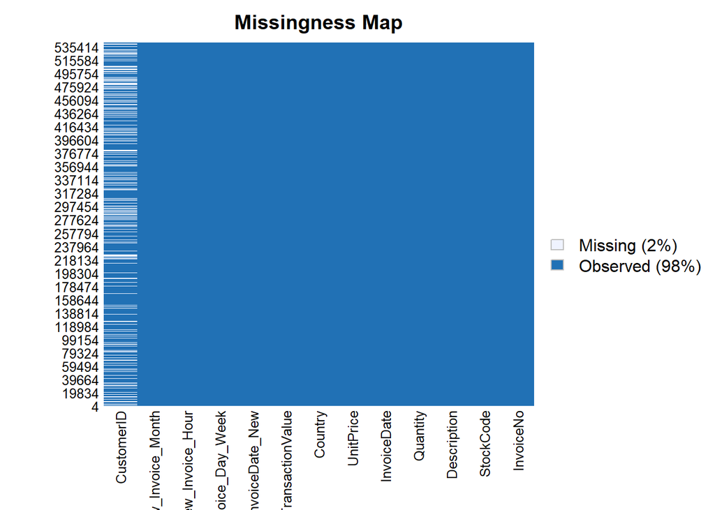

```r
#Just to check the missingness of data overall
#install.packages('Amelia')
library(Amelia)
#visualize the missing data
missmap(mydata)
```

#Que 9 On average, how often the costumers comeback to the website for their next shopping? (i.e. what is the average number of days between consecutive shopping)

```r
#When we looked at the structure of dataset, we saw that the InvoiceDate is presented in char, let's convert this to date so we can use the diff function.

mydata$InvoiceDate <- as.Date(mydata$InvoiceDate, "%m/%d/%Y")


transactions9 <- mydata %>% group_by(CustomerID) %>%  summarise(LatestPurchase = max(InvoiceDate),OldestPurchase= min(InvoiceDate), Timediff= (LatestPurchase - OldestPurchase), AvgDaysBetweenShopping= Timediff/n())
as.data.frame(head(transactions9))
```

```
##   CustomerID LatestPurchase OldestPurchase Timediff AvgDaysBetweenShopping
## 1      12346     2011-01-18     2011-01-18   0 days          0.000000 days
## 2      12347     2011-12-07     2010-12-07 365 days          2.005495 days
## 3      12348     2011-09-25     2010-12-16 283 days          9.129032 days
## 4      12349     2011-11-21     2011-11-21   0 days          0.000000 days
## 5      12350     2011-02-02     2011-02-02   0 days          0.000000 days
## 6      12352     2011-11-03     2011-02-16 260 days          2.736842 days
```

#Que 10 In the retail sector, it is very important to understand the return rate of the goods purchased by customers. In this example, we can define this quantity, simply, as the ratio of the number of transactions cancelled (regardless of the transaction value) over the total number of transactions. With this definition, what is the return rate for the French customers?

```r
TotalTransactions<- mydata %>% filter(Country=="France") %>% summarise(n())
TotalTransactions
```

```
##    n()
## 1 8557
```

```r
CancelledTransactions <- mydata %>% filter(Country=="France" & Quantity <0) %>% summarise(n())
CancelledTransactions
```

```
##   n()
## 1 149
```

```r
ReturnRate <- (CancelledTransactions/TotalTransactions)*100
as.data.frame(ReturnRate)
```

```
##        n()
## 1 1.741264
```

#Que 11 What is the product that has generated the highest revenue for the retailer? (i.e. item with the highest total sum of ‘TransactionValue’).

```r
#We can do this either using stock code or description. Let's first see with StockCode

transactions11 <- mydata %>% group_by(StockCode) %>% summarise(TotalTransaction = sum(TransactionValue)) %>% arrange(desc(TotalTransaction))
as.data.frame(head(transactions11))
```

```
##   StockCode TotalTransaction
## 1       DOT        206245.48
## 2     22423        164762.19
## 3     47566         98302.98
## 4    85123A         97894.50
## 5    85099B         92356.03
## 6     23084         66756.59
```

```r
#Let's now see with Description

transactions11a <- mydata %>% group_by(Description) %>% summarise(TotalTransaction = sum(TransactionValue)) %>% arrange(desc(TotalTransaction))
as.data.frame(head(transactions11a))
```

```
##                          Description TotalTransaction
## 1                     DOTCOM POSTAGE        206245.48
## 2           REGENCY CAKESTAND 3 TIER        164762.19
## 3 WHITE HANGING HEART T-LIGHT HOLDER         99668.47
## 4                      PARTY BUNTING         98302.98
## 5            JUMBO BAG RED RETROSPOT         92356.03
## 6                 RABBIT NIGHT LIGHT         66756.59
```

#Que 12 How many unique customers are represented in the dataset? You can use unique() and length() functions

```r
transactions12 <- unique(mydata$CustomerID)
length(transactions12)
```

```
## [1] 4373
```